# task7_1

Manvydas Sokolovas

19 April 2016

### 1 užduotis:

> The function tsdisplay(data, plot.type=“scatter”) is useful for showing a time plot, ACF plot and lagged scatterplot on the same graph. Use it to produce plots of the following time series: bricksq, hsales, ibmclose. Can you spot the effects of seasonality, cyclicity and trend?

> Užkraunamas “fpp” paketas. Toliau bus naudojami duomenys iš jo:

```r
library("fpp")
```

> Brėžiami duomenų “bricksq” grafikai:

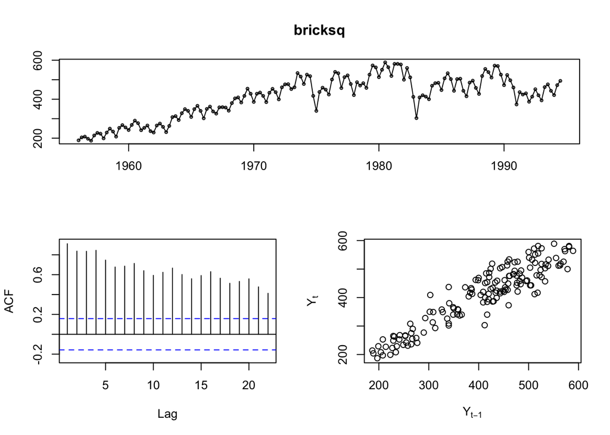

```r
tsdisplay(bricksq, plot.type="scatter")
```

- Sezoniškumas: matomas aiškus sezoniškumas (maži kalneliai - kasmet duomenys kyla ir leidžiasi). Taip pat duomenys pateikti kas ketvirtį, tai imant lagų intervalus po keturis (išeina kas 1 metai) galima ACF grafike matyti sezoniškumą. Taigi ACF grafike matomi svyravimai patvirtina, jog duomenys yra sezoniški.
- Ciklai: galima pastebėti ciklus (ilgi kilimai ir staigūs kritimai) apie:
  - 1)1963-1975m.;
  - 2)1975-1983m.;
  - 3)1983-1991m..
- Trendas: iš grafiko galima įžvelgti kylanti trendą.

> Brėžiami duomenų “hsales” grafikai:

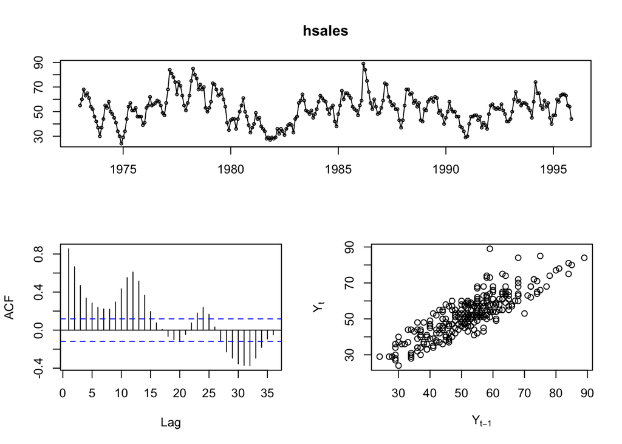

```r
tsdisplay(hsales, plot.type="scatter")
```

- Sezoniškumas: matomas sezoniškumas (smailūs kalneliai). Taip pat duomenys pateikti kas mėnėsį, tai imant lagų intervalus po dvylika (kas 1 metai) galima ACF grafike matyti sezoniškumą. Taigi ACF grafike matomi svyravimai patvirtina, jog duomenys sezoniški.
- Ciklai: galima įžvelgti ciklus (duomenys po truputi kyla ir leidžiasi) apie:
  - 1)1975-1982m.;
  - 2)1982-1991m..
- Trendas: trendo nėra, duomenys svyruoja viename lygyje.

> Brėžiami duomenų “ibmclose” grafikai:

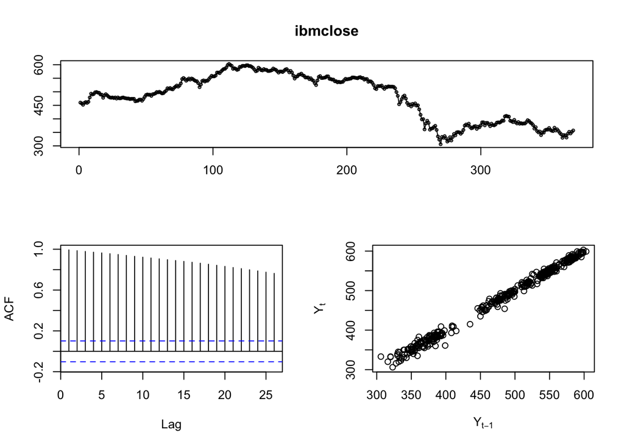

```r
tsdisplay(ibmclose, plot.type="scatter")
```

- Sezoniškumas: iš grafikų galima teigti, jog sezoniškumo nėra.
- Ciklai: galima įžvelgti ciklus (duomenys po truputi kyla ir leidžiasi) apie:
  - 1)0-47;
  - 2)47-270;
  - 3)270-364.
- Trendas: aiškaus trendo nėra.